# Prosper Loan Data Analysis

## Introduction

This data set contains 113,937 loans with 81 variables on each loan, including loan amount, borrower rate (or interest rate), current loan status, borrower income, and many others.

## Preliminary Wrangling

```python
# import all packages and set plots to be embedded inline
import numpy as np
import pandas as pd
import matplotlib.pyplot as plt
import seaborn as sb

%matplotlib inline

# Style and size of graph
sb.set_style('darkgrid')
sb.set(rc={'figure.figsize':(9,7)})

# suppress warnings from final output
import warnings
warnings.simplefilter("ignore")
```

> Load in your dataset and describe its properties through the questions below. Try and motivate your exploration goals through this section.

```python
# reading the files in pandas
df_loan = pd.read_csv("prosperLoanData.csv")
```

```python
# displaying the first five rows of the data
df_loan.head(5)
```

|  | ListingKey | ListingNumber | ListingCreationDate | CreditGrade | Term | LoanStatus | ClosedDate | BorrowerAPR | BorrowerRate | LenderYield | ... | LP_ServiceFees | LP_CollectionFees | LP_GrossPrincipalLoss | LP_NetPrincipalLoss | LP_NonPrincipalRecoverypayments | PercentFunded | Recommendations | InvestmentFromFriendsCount | InvestmentFromFriendsAmount | Investors |
| --- | --- | --- | --- | --- | --- | --- | --- | --- | --- | --- | --- | --- | --- | --- | --- | --- | --- | --- | --- | --- | --- |
| 0 | 1021339766868145413AB3B | 193129 | 2007-08-26 19:09:29.263000000 | C | 36 | Completed | 2009-08-14 00:00:00 | 0.16516 | 0.1580 | 0.1380 | ... | -133.18 | 0.0 | 0.0 | 0.0 | 0.0 | 1.0 | 0 | 0 | 0.0 | 258 |
| 1 | 10273602499503308B223C1 | 1209647 | 2014-02-27 08:28:07.900000000 | NaN | 36 | Current | NaN | 0.12016 | 0.0920 | 0.0820 | ... | 0.00 | 0.0 | 0.0 | 0.0 | 0.0 | 1.0 | 0 | 0 | 0.0 | 1 |
| 2 | 0EE9337825851032864889A | 81716 | 2007-01-05 15:00:47.090000000 | HR | 36 | Completed | 2009-12-17 00:00:00 | 0.28269 | 0.2750 | 0.2400 | ... | -24.20 | 0.0 | 0.0 | 0.0 | 0.0 | 1.0 | 0 | 0 | 0.0 | 41 |
| 3 | 0EF5356002482715299901A | 658116 | 2012-10-22 11:02:35.010000000 | NaN | 36 | Current | NaN | 0.12528 | 0.0974 | 0.0874 | ... | -108.01 | 0.0 | 0.0 | 0.0 | 0.0 | 1.0 | 0 | 0 | 0.0 | 158 |
| 4 | 0F023589499656230C5E3E2 | 909464 | 2013-09-14 18:38:39.097000000 | NaN | 36 | Current | NaN | 0.24614 | 0.2085 | 0.1985 | ... | -60.27 | 0.0 | 0.0 | 0.0 | 0.0 | 1.0 | 0 | 0 | 0.0 | 20 |

5 rows × 81 columns

```python
# description of the data
df_loan.describe()
```

|  | ListingNumber | Term | BorrowerAPR | BorrowerRate | LenderYield | EstimatedEffectiveYield | EstimatedLoss | EstimatedReturn | ProsperRating (numeric) | ProsperScore | ... | LP_ServiceFees | LP_CollectionFees | LP_GrossPrincipalLoss | LP_NetPrincipalLoss | LP_NonPrincipalRecoverypayments | PercentFunded | Recommendations | InvestmentFromFriendsCount | InvestmentFromFriendsAmount | Investors |
| --- | --- | --- | --- | --- | --- | --- | --- | --- | --- | --- | --- | --- | --- | --- | --- | --- | --- | --- | --- | --- | --- |
| count | 1.139370e+05 | 113937.000000 | 113912.000000 | 113937.000000 | 113937.000000 | 84853.000000 | 84853.000000 | 84853.000000 | 84853.000000 | 84853.000000 | ... | 113937.000000 | 113937.000000 | 113937.000000 | 113937.000000 | 113937.000000 | 113937.000000 | 113937.000000 | 113937.000000 | 113937.000000 | 113937.000000 |
| mean | 6.278857e+05 | 40.830248 | 0.218828 | 0.192764 | 0.182701 | 0.168661 | 0.080306 | 0.096068 | 4.072243 | 5.950067 | ... | -54.725641 | -14.242698 | 700.446342 | 681.420499 | 25.142686 | 0.998584 | 0.048027 | 0.023460 | 16.550751 | 80.475228 |
| std | 3.280762e+05 | 10.436212 | 0.080364 | 0.074818 | 0.074516 | 0.068467 | 0.046764 | 0.030403 | 1.673227 | 2.376501 | ... | 60.675425 | 109.232758 | 2388.513831 | 2357.167068 | 275.657937 | 0.017919 | 0.332353 | 0.232412 | 294.545422 | 103.239020 |
| min | 4.000000e+00 | 12.000000 | 0.006530 | 0.000000 | -0.010000 | -0.182700 | 0.004900 | -0.182700 | 1.000000 | 1.000000 | ... | -664.870000 | -9274.750000 | -94.200000 | -954.550000 | 0.000000 | 0.700000 | 0.000000 | 0.000000 | 0.000000 | 1.000000 |
| 25% | 4.009190e+05 | 36.000000 | 0.156290 | 0.134000 | 0.124200 | 0.115670 | 0.042400 | 0.074080 | 3.000000 | 4.000000 | ... | -73.180000 | 0.000000 | 0.000000 | 0.000000 | 0.000000 | 1.000000 | 0.000000 | 0.000000 | 0.000000 | 2.000000 |
| 50% | 6.005540e+05 | 36.000000 | 0.209760 | 0.184000 | 0.173000 | 0.161500 | 0.072400 | 0.091700 | 4.000000 | 6.000000 | ... | -34.440000 | 0.000000 | 0.000000 | 0.000000 | 0.000000 | 1.000000 | 0.000000 | 0.000000 | 0.000000 | 44.000000 |
| 75% | 8.926340e+05 | 36.000000 | 0.283810 | 0.250000 | 0.240000 | 0.224300 | 0.112000 | 0.116600 | 5.000000 | 8.000000 | ... | -13.920000 | 0.000000 | 0.000000 | 0.000000 | 0.000000 | 1.000000 | 0.000000 | 0.000000 | 0.000000 | 115.000000 |
| max | 1.255725e+06 | 60.000000 | 0.512290 | 0.497500 | 0.492500 | 0.319900 | 0.366000 | 0.283700 | 7.000000 | 11.000000 | ... | 32.060000 | 0.000000 | 25000.000000 | 25000.000000 | 21117.900000 | 1.012500 | 39.000000 | 33.000000 | 25000.000000 | 1189.000000 |

8 rows × 61 columns

```python
# information about the data
df_loan.info()
```

```
<class 'pandas.core.frame.DataFrame'>
RangeIndex: 113937 entries, 0 to 113936
Data columns (total 81 columns):
 #   Column                               Non-Null Count   Dtype
---  ------                               --------------   -----
 0   ListingKey                           113937 non-null  object
 1   ListingNumber                        113937 non-null  int64
 2   ListingCreationDate                  113937 non-null  object
 3   CreditGrade                          28953 non-null   object
 4   Term                                 113937 non-null  int64
 5   LoanStatus                           113937 non-null  object
 6   ClosedDate                           55089 non-null   object
 7   BorrowerAPR                          113912 non-null  float64
 8   BorrowerRate                         113937 non-null  float64
 9   LenderYield                          113937 non-null  float64
```

[output cut: 73 more lines]

```python
# to check for duplicated rows and columns
df_loan.duplicated().sum()
```

```
0
```

```python
# check for nulls
df_loan.isnull().sum()
```

```
ListingKey                         0
ListingNumber                      0
ListingCreationDate                0
CreditGrade                    84984
Term                               0
                               ...
PercentFunded                      0
Recommendations                    0
InvestmentFromFriendsCount         0
InvestmentFromFriendsAmount        0
Investors                          0
Length: 81, dtype: int64
```

```python
# taking part of the columns that are needed for the analysis
cols = ['LoanStatus', 'BorrowerAPR', 'EmploymentStatus', 'StatedMonthlyIncome',
        'IncomeVerifiable', 'DebtToIncomeRatio', 'LoanOriginalAmount', 'Term', 'IsBorrowerHomeowner', 'MonthlyLoanPayment',
        'ProsperRating (Alpha)', 'IncomeRange', 'ProsperScore', 'BorrowerRate', 'ListingCategory (numeric)', 'Occupation']
loan_set = df_loan[cols]
```

```python
list_dict = {0 : 'Not Available', 1 : 'Debt Consolidation', 2 : 'Home Improvement', 3: 'Business',
             4 : 'Personal Loan', 5 : 'Student Use', 6 : 'Auto', 7 : 'Other', 8 : 'Baby&Adoption',
             9 : 'Boat', 10 : 'Cosmetic Procedure', 11 : 'Engagement Ring', 12 : 'Green Loans',
             13 : 'Household Expenses', 14 : 'Large Purchases', 15 : 'Medical/Dental', 16 : 'Motorcycle',
             17 : 'RV', 18 : 'Taxes', 19 : 'Vacation', 20 : 'Wedding Loans'}

loan_set['ListingCategory'] = loan_set['ListingCategory (numeric)'].map(list_dict)
loan_set.drop(['ListingCategory (numeric)'], axis=1, inplace=True)
```

```python
# showing the first ten rows of the data
loan_set.info()
```

```
<class 'pandas.core.frame.DataFrame'>
RangeIndex: 113937 entries, 0 to 113936
Data columns (total 16 columns):
 #   Column                 Non-Null Count   Dtype
---  ------                 --------------   -----
 0   LoanStatus             113937 non-null  object
 1   BorrowerAPR            113912 non-null  float64
 2   EmploymentStatus       111682 non-null  object
 3   StatedMonthlyIncome    113937 non-null  float64
 4   IncomeVerifiable       113937 non-null  bool
 5   DebtToIncomeRatio      105383 non-null  float64
 6   LoanOriginalAmount     113937 non-null  int64
 7   Term                   113937 non-null  int64
 8   IsBorrowerHomeowner    113937 non-null  bool
 9   MonthlyLoanPayment     113937 non-null  float64
 10  ProsperRating (Alpha)  84853 non-null   object
 11  IncomeRange            113937 non-null  object
 12  ProsperScore           84853 non-null   float64
 13  BorrowerRate           113937 non-null  float64
 14  Occupation             110349 non-null  object
 15  ListingCategory        113937 non-null  object
dtypes: bool(2), float64(6), int64(2), object(6)
memory usage: 12.4+ MB
```

```python
# overview of the dataset descriptive statistics
loan_set.describe()
```

|  | BorrowerAPR | StatedMonthlyIncome | DebtToIncomeRatio | LoanOriginalAmount | Term | MonthlyLoanPayment | ProsperScore | BorrowerRate |
| --- | --- | --- | --- | --- | --- | --- | --- | --- |
| count | 113912.000000 | 1.139370e+05 | 105383.000000 | 113937.00000 | 113937.000000 | 113937.000000 | 84853.000000 | 113937.000000 |
| mean | 0.218828 | 5.608026e+03 | 0.275947 | 8337.01385 | 40.830248 | 272.475783 | 5.950067 | 0.192764 |
| std | 0.080364 | 7.478497e+03 | 0.551759 | 6245.80058 | 10.436212 | 192.697812 | 2.376501 | 0.074818 |
| min | 0.006530 | 0.000000e+00 | 0.000000 | 1000.00000 | 12.000000 | 0.000000 | 1.000000 | 0.000000 |
| 25% | 0.156290 | 3.200333e+03 | 0.140000 | 4000.00000 | 36.000000 | 131.620000 | 4.000000 | 0.134000 |
| 50% | 0.209760 | 4.666667e+03 | 0.220000 | 6500.00000 | 36.000000 | 217.740000 | 6.000000 | 0.184000 |
| 75% | 0.283810 | 6.825000e+03 | 0.320000 | 12000.00000 | 36.000000 | 371.580000 | 8.000000 | 0.250000 |
| max | 0.512290 | 1.750003e+06 | 10.010000 | 35000.00000 | 60.000000 | 2251.510000 | 11.000000 | 0.497500 |

```python
# Covert LoanStatus and EmploymentStatus into ordered categorical types
ordinal_var_dic = {'EmploymentStatus': ['Employed', 'Full-time', 'Self-employed', 'Not available', 'Other',
                                  'Part-time', 'Not employed', 'Retired'],
                  'LoanStatus': ['Current', 'Completed', 'Chargedoff', 'Defaulted', 'Past Due (1-15 days)',
                                 'Past Due (31-60 days)', 'Past Due (61-90 days)', 'Past Due (91-120 days)',
                                 'Past Due (16-30 days)', 'FinalPaymentInProgress',
                                 'Past Due (>120 days)', 'Cancelled'],
                  'IncomeRange': ['$25,000-49,999', '$50,000-74,999', '$100,000+', '$75,000-99,999',
                                  'Not displayed', '$1-24,999', 'Not employed', '$0']}

for var in ordinal_var_dic:
    ordered_var = pd.api.types.CategoricalDtype(ordered = True, categories = ordinal_var_dic[var])
    loan_set[var] = loan_set[var].astype(ordered_var)
```

```python
ordinal_var_rating = ['AA', 'A', 'B', 'C', 'D', 'E', 'HR']
ordered_var = pd.api.types.CategoricalDtype(ordered=True, categories=ordinal_var_rating)
loan_set['ProsperRating'] = loan_set['ProsperRating (Alpha)'].astype(ordered_var)
```

```python
loan_set.head()
```

|  | LoanStatus | BorrowerAPR | EmploymentStatus | StatedMonthlyIncome | IncomeVerifiable | DebtToIncomeRatio | LoanOriginalAmount | Term | IsBorrowerHomeowner | MonthlyLoanPayment | ProsperRating (Alpha) | IncomeRange | ProsperScore | BorrowerRate | Occupation | ListingCategory | ProsperRating |
| --- | --- | --- | --- | --- | --- | --- | --- | --- | --- | --- | --- | --- | --- | --- | --- | --- | --- |
| 0 | Completed | 0.16516 | Self-employed | 3083.333333 | True | 0.17 | 9425 | 36 | True | 330.43 | NaN | $25,000-49,999 | NaN | 0.1580 | Other | Not Available | NaN |
| 1 | Current | 0.12016 | Employed | 6125.000000 | True | 0.18 | 10000 | 36 | False | 318.93 | A | $50,000-74,999 | 7.0 | 0.0920 | Professional | Home Improvement | A |
| 2 | Completed | 0.28269 | Not available | 2083.333333 | True | 0.06 | 3001 | 36 | False | 123.32 | NaN | Not displayed | NaN | 0.2750 | Other | Not Available | NaN |
| 3 | Current | 0.12528 | Employed | 2875.000000 | True | 0.15 | 10000 | 36 | True | 321.45 | A | $25,000-49,999 | 9.0 | 0.0974 | Skilled Labor | Motorcycle | A |
| 4 | Current | 0.24614 | Employed | 9583.333333 | True | 0.26 | 15000 | 36 | True | 563.97 | D | $100,000+ | 4.0 | 0.2085 | Executive | Home Improvement | D |

```python
loan_set.ProsperRating.value_counts().index
```

```
CategoricalIndex(['C', 'B', 'A', 'D', 'E', 'HR', 'AA'], categories=['AA', 'A', 'B', 'C', 'D', 'E', 'HR'], ordered=True, dtype='category')
```

### What is the structure of your dataset?

This data set contains 113,937 loans with 81 variables on each loan, including loan amount, borrower rate (or interest rate), current loan status, borrower income, and many others.

### What is/are the main feature(s) of interest in your dataset?

> - What factors affect a loan’s outcome status?
> - What affects the borrower’s APR or interest rate?
> - Are there differences between loans depending on how large the original loan amount was?

## Univariate Exploration

> In this section, I will investigate distributions of individual variables of interest.

#### BorrowerRate

The Borrower's interest rate for this loan.

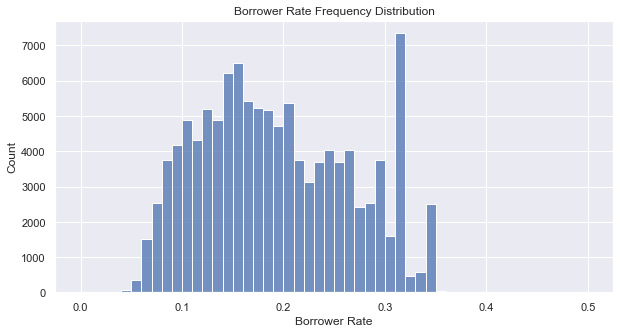

```python
plt.figure(figsize=[10,5])
bins=np.arange(0, loan_set.BorrowerRate.max()+0.01, 0.01)

sb.histplot(data=loan_set, x='BorrowerRate', bins=bins)
plt.xlabel('Borrower Rate')
plt.title('Borrower Rate Frequency Distribution');
```

#### Borrower APR

The Borrower's Annual Percentage Rate (APR) for the loan.

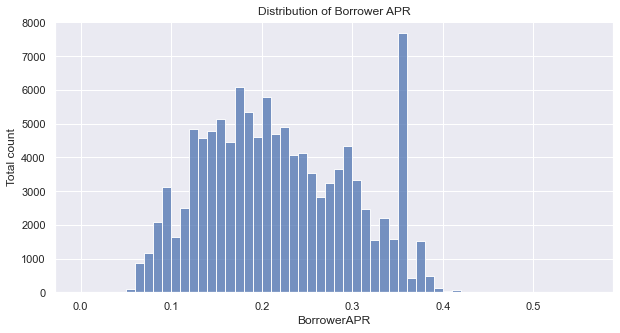

```python
# defing the size of the figure
plt.figure(figsize=[10,5])
bins = np.arange(0, loan_set.BorrowerAPR.max()+0.05, 0.01)

sb.histplot(data=loan_set, x='BorrowerAPR', bins=bins)
plt.xlabel('BorrowerAPR')
plt.ylabel('Total count')
plt.title('Distribution of Borrower APR')
plt.show();
```

#### Prosper Rating

The Prosper Rating assigned at the time the listing was created between AA - HR.

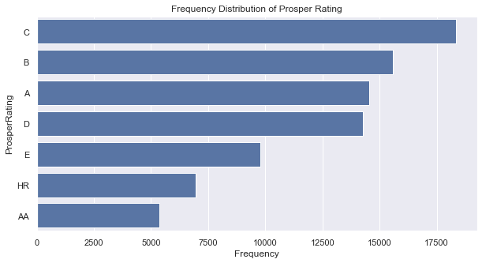

```python
plt.figure(figsize=[10,5])
base_color = sb.color_palette()[0]
base_order = loan_set.ProsperRating.value_counts().index

sb.countplot(data=loan_set, y='ProsperRating', color=base_color, order=base_order)
plt.ylabel('ProsperRating')
plt.xlabel('Frequency')
plt.title('Frequency Distribution of Prosper Rating');
```

This graph shows that most borrowers got a rating of 4. That's, C. Also, it's between A-D.

#### Employment Status

The Employment Status of the borrower

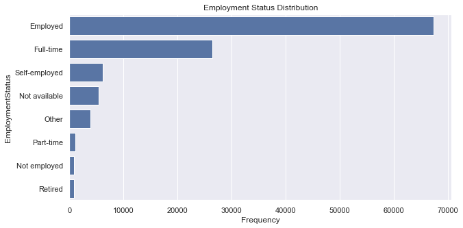

```python
plt.figure(figsize=[10,5])
base_order = loan_set.EmploymentStatus.value_counts().index
base_color = sb.color_palette()[0]

sb.countplot(data = loan_set, y='EmploymentStatus', color=base_color, order=base_order)
plt.ylabel("EmploymentStatus")
plt.xlabel('Frequency')
plt.title('Employment Status Distribution');
```

This graph shows that most of the persons given the loan were employed. The company do not want to give out loans to individuals who are unemployed so as to avoid difficulty in repayment.

#### Loan Status

The current status of the loan: Cancelled, Chargedoff, Completed, Current, Defaulted, FinalPaymentInProgress, PastDue. The PastDue status will be accompanied by a delinquency bucket.

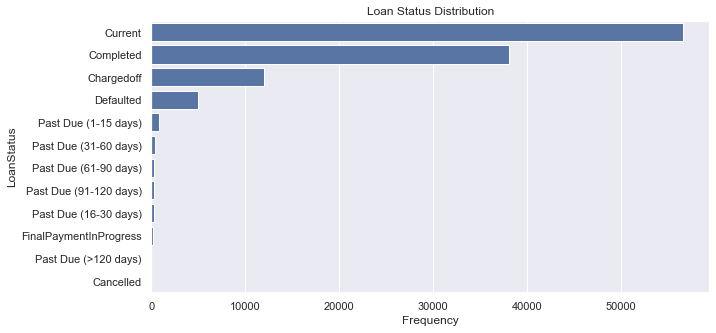

```python
plt.figure(figsize=[10,5])
base_order = loan_set.LoanStatus.value_counts().index
base_color = sb.color_palette()[0]

sb.countplot(data = loan_set, y= 'LoanStatus', color=base_color, order=base_order)
plt.ylabel('LoanStatus')
plt.xlabel('Frequency')
plt.title('Loan Status Distribution');
```

#### Income Range

The income range of the borrower at the time the listing was created.

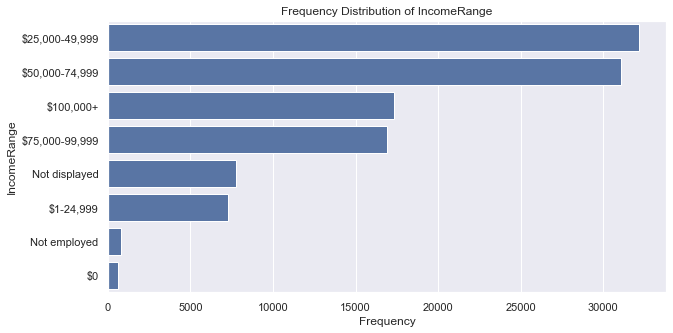

```python
plt.figure(figsize=[10,5])
base_order = loan_set.IncomeRange.value_counts().index
base_color = sb.color_palette()[0]

sb.countplot(data=loan_set, y='IncomeRange', color=base_color, order=base_order)
plt.ylabel('IncomeRange')
plt.xlabel('Frequency')
plt.title('Frequency Distribution of IncomeRange');
```

#### Debt To Income Ratio

The debt to income ratio of the borrower at the time the credit profile was pulled.

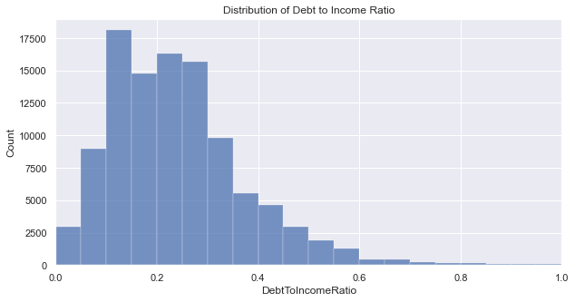

```python
plt.figure(figsize=[10,5])
base_color = sb.color_palette()[0]
base_order = loan_set.DebtToIncomeRatio.value_counts().index

bins = np.arange(0, loan_set.DebtToIncomeRatio.max()+0.05, 0.05)
sb.histplot(data=loan_set, x='DebtToIncomeRatio', bins=bins )
plt.xlabel('DebtToIncomeRatio')
plt.title('Distribution of Debt to Income Ratio')
plt.xlim(0,1);
```

#### MonthlyLoanPayment

The scheduled monthly loan payment.

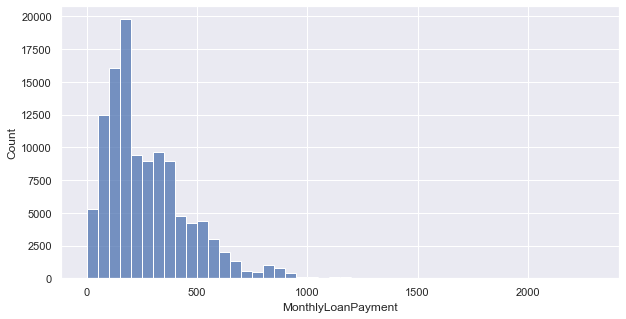

```python
plt.figure(figsize=[10,5])
bins = np.arange(0, loan_set.MonthlyLoanPayment.max()+50, 50)
sb.histplot(data=loan_set, x='MonthlyLoanPayment', bins=bins);
```

This graph shows that most borrowers make little monthly payment. That's most persons make payment less than 1k.

#### Listing Category

The category of the listing that the borrower selected when posting their listing: 0 - Not Available, 1 - Debt Consolidation, 2 - Home Improvement, 3 - Business, 4 - Personal Loan, 5 - Student Use, 6 - Auto, 7- Other, 8 - Baby&Adoption, 9 - Boat, 10 - Cosmetic Procedure, 11 - Engagement Ring, 12 - Green Loans, 13 - Household Expenses, 14 - Large Purchases, 15 - Medical/Dental, 16 - Motorcycle, 17 - RV, 18 - Taxes, 19 - Vacation, 20 - Wedding Loans

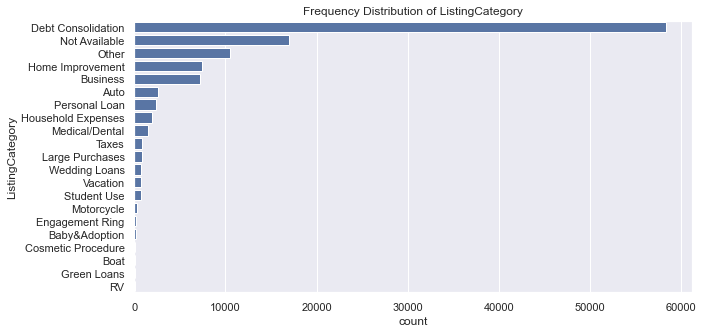

```python
plt.figure(figsize=[10,5])
base_color = sb.color_palette()[0]
base_order = loan_set.ListingCategory.value_counts().index
listing_counts = loan_set['ListingCategory'].value_counts()
sb.countplot(data=loan_set, y='ListingCategory', color=base_color, order=base_order)
plt.ylabel('ListingCategory')
plt.title('Frequency Distribution of ListingCategory');
```

This graph shows that the most common type of loan is Dept consolidation

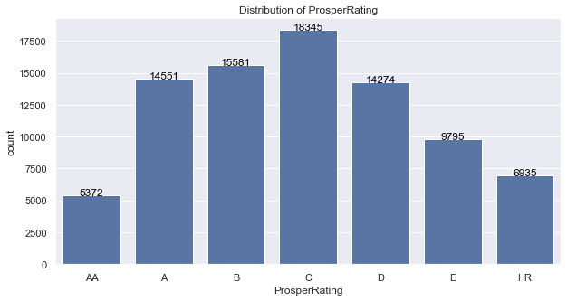

```python
plt.figure(figsize=[10,5])
base_color=sb.color_palette()[0]

sb.countplot(data=loan_set, x='ProsperRating', color=base_color)
plt.title('Distribution of ProsperRating');

locs, labels = plt.xticks()
cat_counts = loan_set.ProsperRating.value_counts()

for loc, label in zip(locs, labels):
    count = cat_counts[(label.get_text())]
    pct_string = '{}'.format(count)
    plt.text(loc, count, pct_string, ha = 'center', color = 'black')
```

The graph shows that most persons have loan rating between A and D.

#### Occupation

The top ten Occupations selected by the Borrower at the time they created the listing.

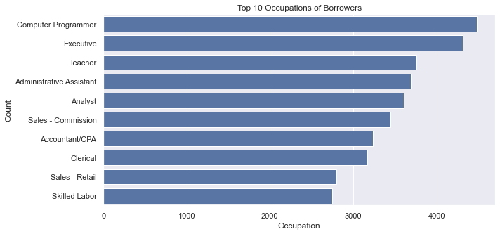

```python
# taking the first 10 popular occupations
top_10_occu = ['Computer Programmer', 'Executive', 'Teacher',
       'Administrative Assistant', 'Analyst', 'Sales - Commission',
       'Accountant/CPA', 'Clerical', 'Sales - Retail', 'Skilled Labor']
sub_occupation = loan_set.loc[loan_set['Occupation'].isin(top_10_occu)]

plt.figure(figsize=[10,5])
sb.countplot(data=sub_occupation, y='Occupation', color=base_color, order=sub_occupation.Occupation.value_counts().index)
plt.xlabel('Occupation')
plt.ylabel('Count')
plt.title('Top 10 Occupations of Borrowers');
```

The graph shows the 10 most popular occupations of the borrowers.

### Discuss the distribution(s) of your variable(s) of interest. Were there any unusual points? Did you need to perform any transformations?

> BorrowerAPR: This shows that there are some spike at 0.1, then 0.18, and then at 0.35 the spike. None of the percentage rate was exceeded

### Of the features you investigated, were there any unusual distributions? Did you perform any operations on the data to tidy, adjust, or change the form of the data? If so, why did you do this?

> EmploymentStatus: This showed that most of the borrowers who recieved the loan are employed.

> LoanStatus: This showed that the the current borrowers above 50,000 are yet to pay their loans.

## Bivariate Exploration

> To start with, i will look at the pairwise correlation of the data to see if there are correlations between the variables

```python
numeric_vars = ['BorrowerRate', 'BorrowerAPR', 'MonthlyLoanPayment', 'DebtToIncomeRatio', 'LoanOriginalAmount',
                'ProsperScore', 'StatedMonthlyIncome']
```

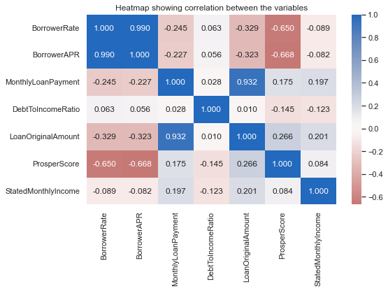

```python
plt.figure(figsize=[8,5])

sb.heatmap(loan_set[numeric_vars].corr(), annot=True, fmt='.3f', cmap='vlag_r', center=0)
plt.title('Heatmap showing correlation between the variables')
plt.show();
```

The heatmap shows there is a strong correlation between BorrowerRate and BorrowerAPR. That's they are both directly proportional. There is a negative correlation between the ProsperScore and BorrowerRate. Meaning the higher the Score, the lower the interest rate. It shows there is a strong positive correlation between the original loan amount and the monthly loan payment.

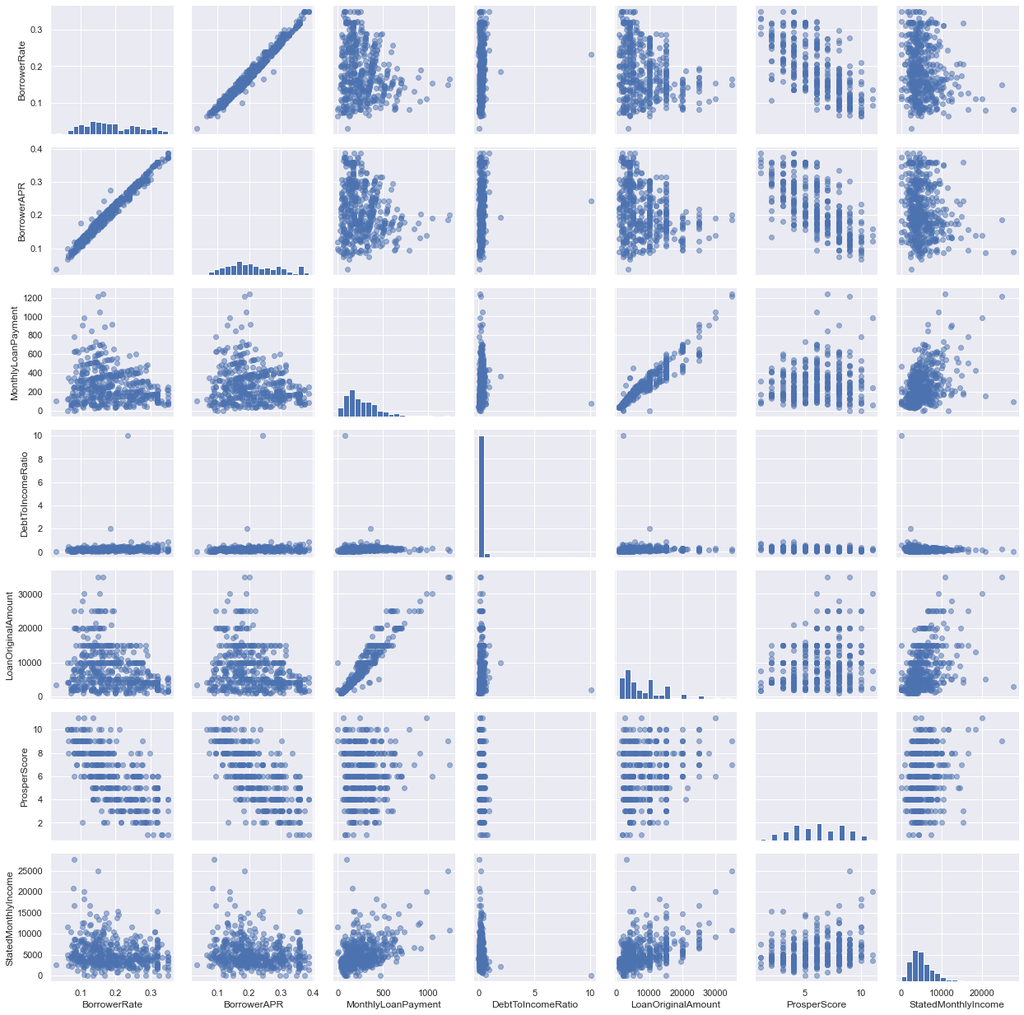

```python
samples = np.random.choice(loan_set.shape[0], 500, replace=False)
loan_samp = loan_set.loc[samples,:]

g=sb.PairGrid(data=loan_samp, vars=numeric_vars)
g=g.map_diag(plt.hist, bins=20)
g.map_offdiag(plt.scatter, alpha=1/2)
plt.show()
```

#### Borrower Rate vs [EmploymentStatus, IsBorrowerHomeowner and IncomeRange]

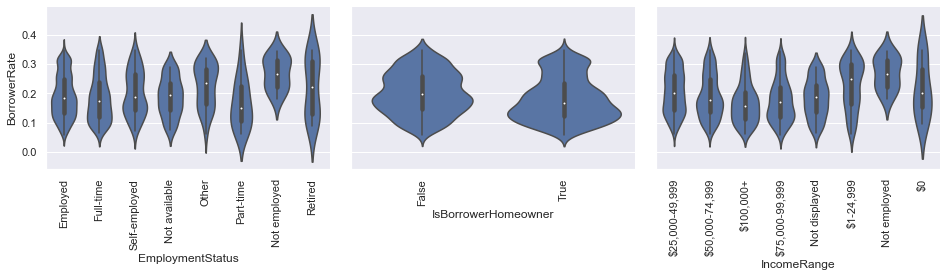

```python
sample = np.random.choice(loan_set.shape[0], 2000, replace=False)
loan_samp = loan_set.loc[sample,:]

def violin(x, y, **kwargs):
    default_color = sb.color_palette()[0]
    sb.violinplot(x, y, color=default_color)
    plt.xticks(rotation=90)

plt.figure(figsize=[20,20])
g = sb.PairGrid(data=loan_samp, y_vars=['BorrowerRate'], x_vars=['EmploymentStatus', 'IsBorrowerHomeowner', 'IncomeRange'],
               size=3, aspect=1.5)
g.map(violin)
plt.show();
```

1. From the graph, there is a correlation between IsBorrowerHomeOwener and BorrowerRate. Those who have a form of collateral is given low interest rate as compare to those who doesn't have a form of collateral.
2. Also, it shows that there is a negative correlation between EmploymentStatus and BorrowerRate. The interest rate for those that are are employed are lower than those who are unemployed.
3. This also shows that the interest rate for those who are employed and earn higher are a bit lower. The more the borrowers earned the less the interest rate.

#### Plotting the graph of BorrowerAPR against some categorical variables

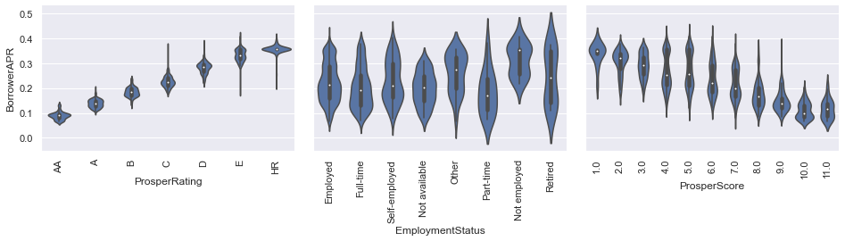

```python
g=sb.PairGrid(data=loan_samp, y_vars=['BorrowerAPR'], x_vars=['ProsperRating', 'EmploymentStatus',
                                                              'ProsperScore'], size=3, aspect=1.5)
g.map(violin)
plt.show();
```

The graph shows that annaul percentage rate for those with low Prosper rating is high, while those with high Prosper rating is low.  
The percentage rate for those with high prosper score is low, while that with high prosper score is low. This shows there's a correlation between prosper rating and Prosper score.

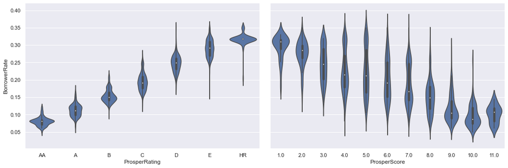

```python
sample = np.random.choice(loan_set.shape[0], 2000, replace=False)
loan_samp = loan_set.loc[sample,:]
plt.figure(figsize=[20,20])

def violin(x, y, **kwargs):
    default_color = sb.color_palette()[0]
    sb.violinplot(x, y, color=default_color)

# plotting the graph
g = sb.PairGrid(data=loan_samp, y_vars=['BorrowerRate'], x_vars=['ProsperRating', 'ProsperScore'],
               size=5, aspect=1.5)
g.map(violin)
plt.show();
```

The graph tells us that the borrowers with good prosper rating are likely to pay less interest rate. It also shows that good prosper score means lower interest rate. The higher the borrower's rating, the lesser the interest rate. And the higher the score, the lesser the interest rate.

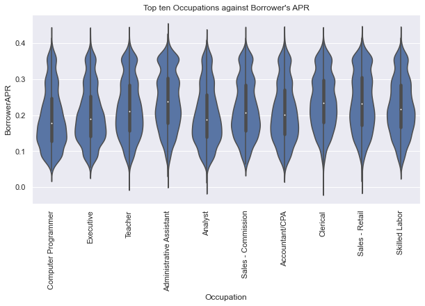

```python
plt.figure(figsize=[10,5])
base_order = sub_occupation.Occupation.value_counts().index

g= sb.violinplot(data=sub_occupation, x='Occupation', y='BorrowerAPR', color=sb.color_palette()[0], order = base_order)
plt.xticks(rotation=90);
plt.title("Top ten Occupations against Borrower's APR");
```

As seen before let's take for the top ten occupations

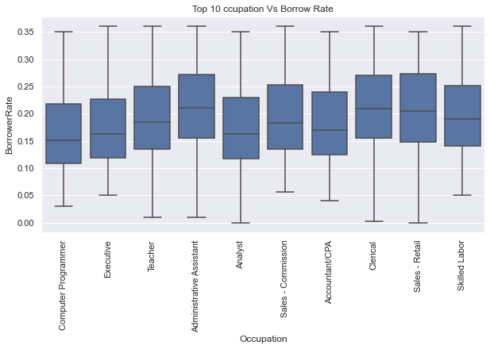

```python
plt.figure(figsize=[10,5])
base_color=sb.color_palette()[0]
base_order = sub_occupation.Occupation.value_counts().index
sb.boxplot(data=loan_set, x='Occupation', y='BorrowerRate', order=base_order,
              color=base_color)
plt.xticks(rotation=90)
plt.title('Top 10 ccupation Vs Borrow Rate');
```

This shows that the among the top ten executives, 'Administrative Assistant' has the most interest rate.

### Did you observe any interesting relationships between the other features (not the main feature(s) of interest)?

> As seen form the graph between interest rate and top 10 occupations, i am wondering why the administrative assistants got the loan on the basis that he/she would pay higher interest rate compared to computer programmer and others.

## Multivariate Exploration

> Create plots of three or more variables to investigate your data even further. Make sure that your investigations are justified, and follow from your work in the previous sections.

##### BorrowerRate Vs prosperScore Vs EmploymentStatus

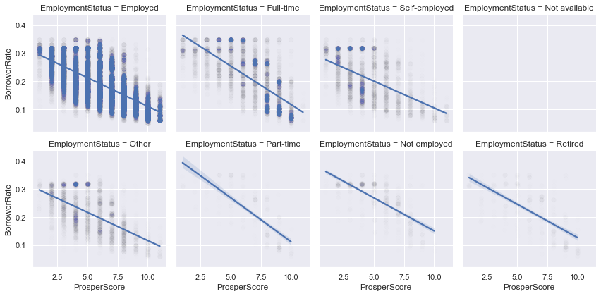

```python
numeric_vars = ['BorrowerRate', 'BorrowerAPR', 'MonthlyLoanPayment', 'DebtToIncomeRatio', 'LoanOriginalAmount',
                'ProsperScore', 'StatedMonthlyIncome']

cat_var = ['IncomeRange', 'LoanStatus', 'ProsperRating', 'EmploymentStatus']

g=sb.FacetGrid(data=loan_set, col='EmploymentStatus', col_wrap=4, size=3)
g.map(sb.regplot, 'ProsperScore', 'BorrowerRate', x_jitter = 0.06, scatter_kws={'alpha':0.005});
```

As seen from the graph, the employemnt status of the borrowers has much to do the prosper score and the interest rate. The Prosper Loan company scores each intending borrower based on their employment status. They now assign interest rate based on the score. If an intending borrower has a high score, the interest rate is brought down. This is because he knows they would pay with a shorter period compare to those who are not employed.

##### StatedMonthlyIncome Vs BorrowerRate Vs ProsperRating

```python
g=sb.FacetGrid(data=loan_set, col='ProsperRating', col_wrap=4, size=3)
g.map(sb.regplot, 'StatedMonthlyIncome', 'BorrowerRate', x_jitter = 0.6, scatter_kws={'alpha':0.005});
```

[output not shown]

##### ProsperScore Vs BorrowerRate Vs IsBorrowerHomeowner

```python
plt.figure(figsize=[10,5])
sb.boxplot(data=loan_set, x='ProsperScore', y='BorrowerRate', hue='IsBorrowerHomeowner');
```

[output not shown]

### Talk about some of the relationships you observed in this part of the investigation. Were there features that strengthened each other in terms of looking at your feature(s) of interest?

> As seen from the graph, the employemnt status of the borrowers has much to do the prosper score and the interest rate. The Prosper Loan company scores each intending borrower based on their employment status. They now assign interest rate based on the score. If an intending borrower has a high score, the interest rate is brought down. This is because he knows they would pay with a shorter period compare to those who are not employed.

## Conclusions

> From the analysis, the Prosper Loan Service gives loans to indviduals. To be able to access the loan, there are criterials the company uses in other to assess the indiduals' payback ability. This is to ensure the borrowers pay back within the minimum time possible. Such ciriterials include and not limited to Employment status, individuals monthly income and if the individuals have any collateral which in this case is house. These factors are then considered to be rate and score the individual, Prosper rating and Prosper score respectively. As such, the interest rate and annual interest rate are inversely proportional to these factors.

> Futhermore, we saw that there was a correlation between the loan original amount and the monthly loan payment. That's, those who collected higher amount paid more monthly.